# StatsProject2_eric

Eric Laigaie

3/18/2022

Loading in packages

Data is stored in a .data and .test file. Let’s read them as .csvs & define the column names.

```r
#columns = c('age', 'workclass', 'fnlwgt', 'education', 'education_num', 'marital_status', 'occupation', 'relationship', #'race', 'sex', 'capital_gain', 'capital_loss', 'hours_per_week', 'native_country', 'pay_response')

#df_train <- read_csv("C:\\Users\\ericl\\OneDrive\\Desktop\\SMU\\Applied Statistics - SPRING 2022\\Project 2\\adult.data", col_names=columns)
#df_test <- read_csv("C:\\Users\\ericl\\OneDrive\\Desktop\\SMU\\Applied Statistics - SPRING 2022\\Project 2\\adult.test", col_names = columns)

df_train <- read.csv("https://raw.githubusercontent.com/ericlaigaie/StatsProject_2/main/train.csv")
df_test <- read.csv("https://raw.githubusercontent.com/ericlaigaie/StatsProject_2/main/test.csv")
```

Checking for any null values.

```r
colSums(is.na(df_train))
```

```
##             id            age      workclass         fnlwgt      education
##              0              0              0              0              0
##  education_num marital_status     occupation   relationship           race
##              0              0              0              0              0
##            sex   capital_gain   capital_loss hours_per_week native_country
##              0              0              0              0              0
##   pay_response
##              0
```

```r
colSums(is.na(df_test))
```

```
##             id            age      workclass         fnlwgt      education
##              0              0              0              0              0
##  education_num marital_status     occupation   relationship           race
##              0              0              0              0              0
##            sex   capital_gain   capital_loss hours_per_week native_country
##              0              0              0              0              0
##   pay_response
##              0
```

Neither dataset shows any missing values…makes sense, considering it’s manufactured set from UCI. However, we’ll have to watch out for any values listed as ‘null’, ‘N/A’, etc. that would not appear missing.

Writing datasets out to actual .csvs.

```r
#write.csv(df_train, "C:\\Users\\ericl\\OneDrive\\Desktop\\SMU\\Applied Statistics - SPRING 2022\\Project 2\\train.csv")
#write.csv(df_test, "C:\\Users\\ericl\\OneDrive\\Desktop\\SMU\\Applied Statistics - SPRING 2022\\Project 2\\test.csv")
```

# Numerical variables exploration…

Usually a ggpairs is pretty useful to start out an EDA.

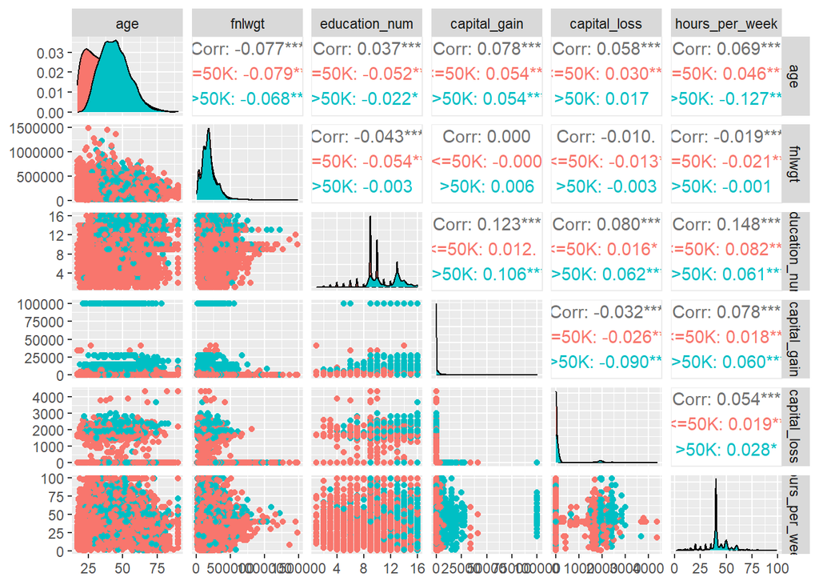

```r
ggpairs(df_train, columns = c(2,4,6,12,13,14), ggplot2::aes(colour=pay_response))
```

This is a little busy for me. I’ll explore more in-depth below. ***However, let’s keep this code since it produces all the correlation values super easily.

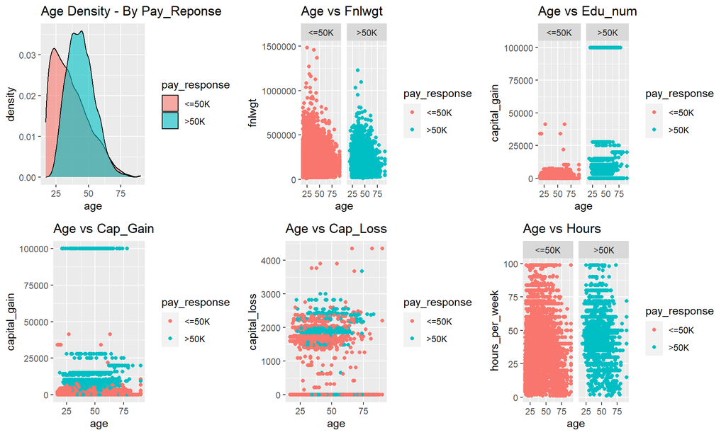

```r
age <- ggplot(df_train, aes(x=age, fill=pay_response)) + geom_density(alpha=.6) + labs(title='Age Density - By Pay_Reponse')
fnlwgt <- ggplot(df_train, aes(x=age, y=fnlwgt, color=pay_response)) + geom_point() + labs(title='Age vs Fnlwgt') + facet_wrap(~pay_response)
edu_num <- ggplot(df_train, aes(x=age, y=capital_gain, color=pay_response)) + geom_point() + labs(title='Age vs Edu_num') + facet_wrap(~pay_response)
cap_gain <- ggplot(df_train, aes(x=age, y=capital_gain, color=pay_response)) + geom_point() + labs(title='Age vs Cap_Gain')
cap_loss <- ggplot(df_train, aes(x=age, y=capital_loss, color=pay_response)) + geom_point() + labs(title='Age vs Cap_Loss')
hours <- ggplot(df_train, aes(x=age, y=hours_per_week, color=pay_response)) + geom_point() + labs(title='Age vs Hours') + facet_wrap(~pay_response)

ggarrange(age, fnlwgt, edu_num, cap_gain, cap_loss, hours, nrow=2, ncol=3)
```

AGE DENSITY : Looks fine. The trend is especially apparent in the red curve.

AGE VS FNLWGT : I had to look this up, but ‘Fnlwgt’ means ‘final weight’: This is the number of people that the census believes the point represents. I’m not sure how this would fit into the pay_response model, so we’ll have to evaluate it’s inclusion. As we can see, there are a bit of outliers. However, these outliers, if correct, count for +1M people, so….it’s weird.

AGE VS EDU NUM : While the relationship with pay_response appears pretty valid, some more exploration into capital_gain and education can help us understand what each ‘num’ represents. I imagine education and capital_gain have a high amount of collinearity, so we’ll have to evaluate which variable goes into the model.

AGE VS CAP GAIN : I don’t really like this variable. I don’t have a ton of understanding of what capital gain is, and the weird collection of outliers makes me think there is a limit to this variable.

AGE VS CAP_LOSS : This variable appears a little better to me. However, the trend is a little odd. I guess the takeaway is that the blue group has very few observations towards the bottom of the set.

AGE VS HOURS : I will have to visit this again and try to find a better way to visualize this.

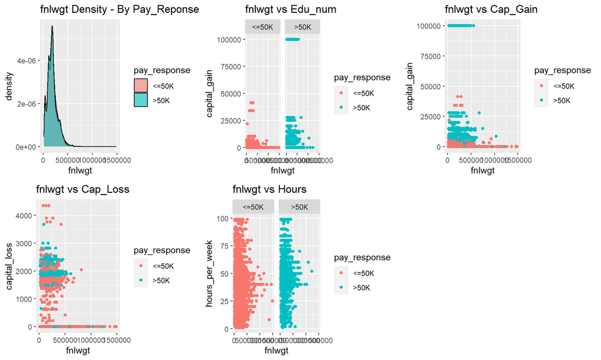

```r
fnlwgt <- ggplot(df_train, aes(x=fnlwgt, fill=pay_response)) + geom_density(alpha=.6) + labs(title='fnlwgt Density - By Pay_Reponse')
edu_num <- ggplot(df_train, aes(x=fnlwgt, y=capital_gain, color=pay_response)) + geom_point() + labs(title='fnlwgt vs Edu_num') + facet_wrap(~pay_response)
cap_gain <- ggplot(df_train, aes(x=fnlwgt, y=capital_gain, color=pay_response)) + geom_point() + labs(title='fnlwgt vs Cap_Gain')
cap_loss <- ggplot(df_train, aes(x=fnlwgt, y=capital_loss, color=pay_response)) + geom_point() + labs(title='fnlwgt vs Cap_Loss')
hours <- ggplot(df_train, aes(x=fnlwgt, y=hours_per_week, color=pay_response)) + geom_point() + labs(title='fnlwgt vs Hours') + facet_wrap(~pay_response)

ggarrange(fnlwgt, edu_num, cap_gain, cap_loss, hours, nrow=2, ncol=3)
```

FNLWGT DENSITY : It doesn’t appear like there’s a relationship between fnlwgt and the response at all.

FNLWGT VS EDU_NUM : Not much relationship.

FNLWGT VS CAP_GAIN : Although you can take some cap_gain and pay_response relationship from this, the fnlwgt doesn’t show me much.

FNLWGT VS CAP_LOSS : Same thing from the cap_gain feedback.

FNLWGT VS HOURS : Yeah, I would be surprised if this variable is meaningful within any regression model.

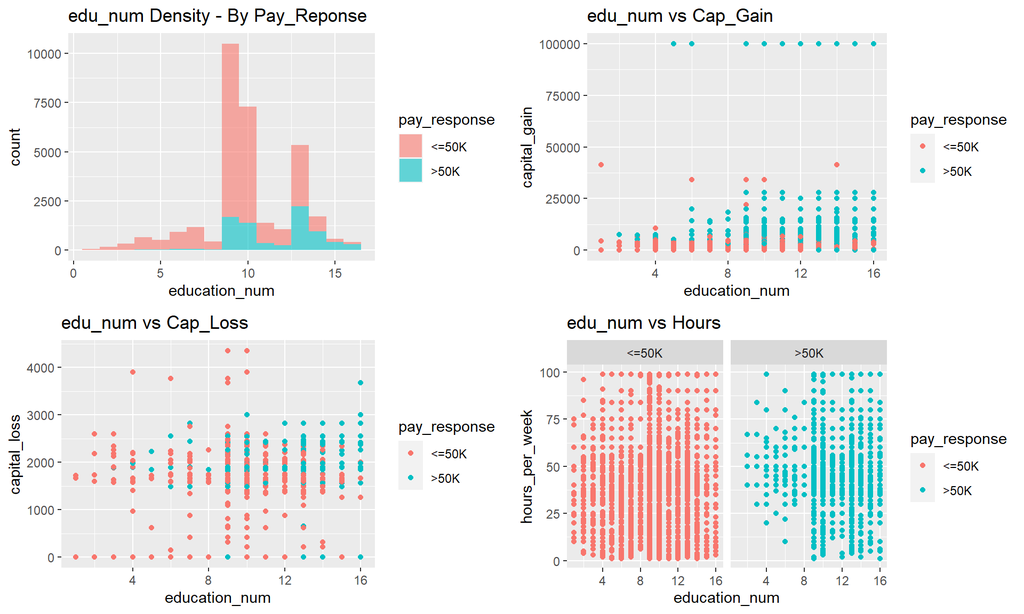

```r
edu_num <- ggplot(df_train, aes(x=education_num, fill=pay_response)) + geom_histogram(alpha=.6, binwidth=1) + labs(title='edu_num Density - By Pay_Reponse')
cap_gain <- ggplot(df_train, aes(x=education_num, y=capital_gain, color=pay_response)) + geom_point() + labs(title='edu_num vs Cap_Gain')
cap_loss <- ggplot(df_train, aes(x=education_num, y=capital_loss, color=pay_response)) + geom_point() + labs(title='edu_num vs Cap_Loss')
hours <- ggplot(df_train, aes(x=education_num, y=hours_per_week, color=pay_response)) + geom_point() + labs(title='edu_num vs Hours') + facet_wrap(~pay_response)

ggarrange(edu_num, cap_gain, cap_loss, hours, nrow=2, ncol=2)
```

EDU_NUM DENSITY : This looks fine, pay_response is what you would expect. More exploration on the capital_gain vs education below.

EDU_NUM VS CAP_GAIN : This also appears how I would expect, I just don’t love the way I visualized it.

EDU_NUM VS CAP_LOSS : This is a little more confusing to me. I would expect the blue dot to trend lower, but I understand that as edu_num increases, there is much less red population, so the blue would appear more prevalent.

EDU_NUM VS HOURS : The education vs pay_response relationship also looks good here, given the scarcity of low edu_num blue population. Again, there is a better way to visualize this.

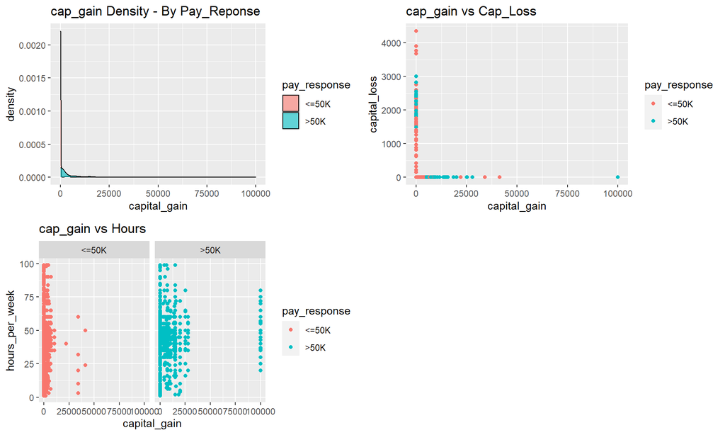

```r
cap_gain <- ggplot(df_train, aes(x=capital_gain, fill=pay_response)) + geom_density(alpha=.6) + labs(title='cap_gain Density - By Pay_Reponse')
cap_loss <- ggplot(df_train, aes(x=capital_gain, y=capital_loss, color=pay_response)) + geom_point() + labs(title='cap_gain vs Cap_Loss')
hours <- ggplot(df_train, aes(x=capital_gain, y=hours_per_week, color=pay_response)) + geom_point() + labs(title='cap_gain vs Hours') + facet_wrap(~pay_response)

ggarrange(cap_gain, cap_loss, hours, nrow=2, ncol=2)
```

First draft: Outliers must be kicked out of the chart to show us anything.

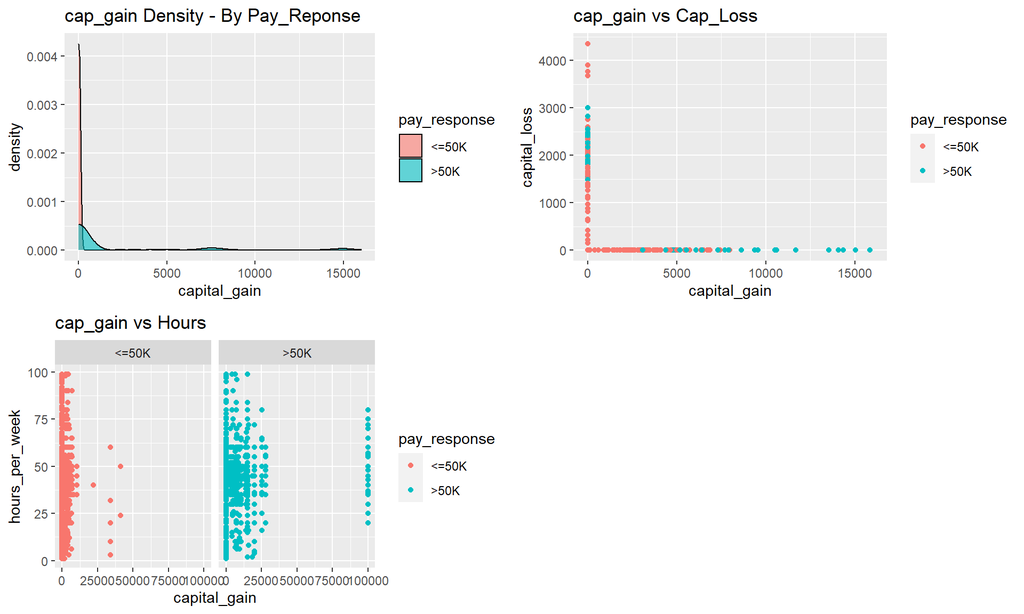

```r
cap_gain <- ggplot(df_train, aes(x=capital_gain, fill=pay_response)) + geom_density(alpha=.6) + labs(title='cap_gain Density - By Pay_Reponse') + xlim(0, 16000)
cap_loss <- ggplot(df_train, aes(x=capital_gain, y=capital_loss, color=pay_response)) + geom_point() + labs(title='cap_gain vs Cap_Loss') + xlim(0, 16000)
hours <- ggplot(df_train, aes(x=capital_gain, y=hours_per_week, color=pay_response)) + geom_point() + labs(title='cap_gain vs Hours') + facet_wrap(~pay_response)

ggarrange(cap_gain, cap_loss, hours, nrow=2, ncol=2)
```

CAP_GAIN DENSITY : I could filter out more xlims, but the small bumps at ~7500 and ~15000 show overwhelmingly blue population, and I think that’s meaningful. What I would expect looking at cap_gains with a income response variable.

CAP_LOSS VS CAP_GAIN : Looks extremely similar to the first chart, just in dot form. What is weird to me is the 0 gain, ~2000-3000 loss blue population.

CAP_GAIN VS HOURS : It is odd to me that the high-hours don’t show a higher capital gain, but maybe I’m just misundertanding capital gain. However, we still see blue dominates the higher range of cap gain.

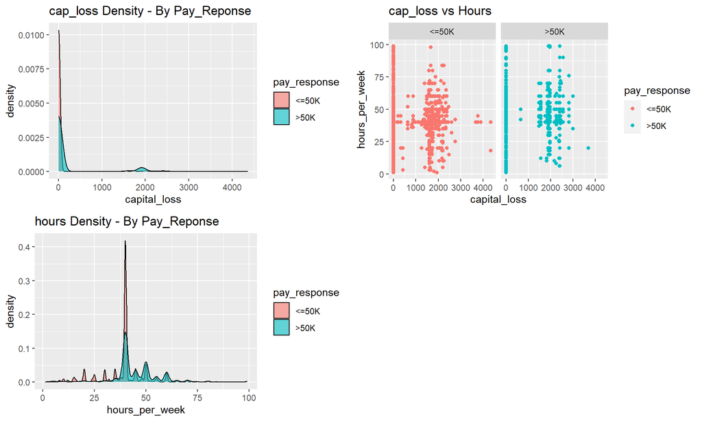

```r
cap_loss <- ggplot(df_train, aes(x=capital_loss, fill=pay_response)) + geom_density(alpha=.6) + labs(title='cap_loss Density - By Pay_Reponse')
hours <- ggplot(df_train, aes(x=capital_loss, y=hours_per_week, color=pay_response)) + geom_point() + labs(title='cap_loss vs Hours') + facet_wrap(~pay_response)
hoursdensity <- ggplot(df_train, aes(x=hours_per_week, fill=pay_response)) + geom_density(alpha=.6) + labs(title='hours Density - By Pay_Reponse')

ggarrange(cap_loss, hours, hoursdensity, nrow=2, ncol=2)
```

CAP_LOSS DENSITY : Again, I’m surprised that the blue population is more prevalent at higher cap_loss. However, maybe this can be explained because they simply have more capital to lose.

CAP_LOSS VS HOURS : Don’t think there’s much difference here between pay groups, other than the blue population tending to skew higher on cap_loss when above 0.

HOURS DENSITY : Obviously, huge spike at 40. The colors make sense to me…lower hours_per_week would skew more red, and that is what we see.

# On to categorical variables…

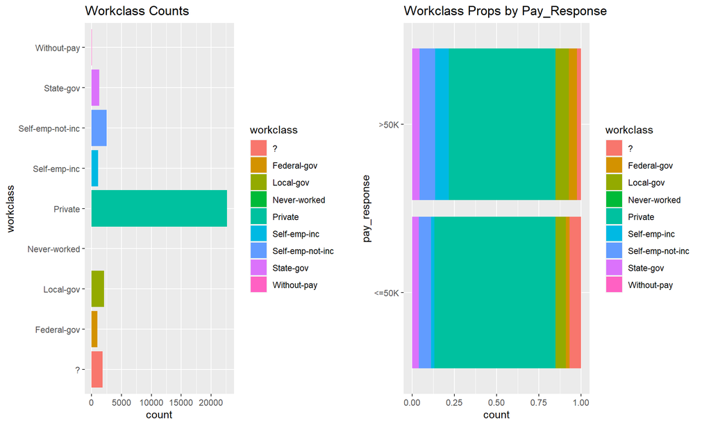

```r
count <- ggplot(df_train, aes(y=workclass, fill=workclass)) + geom_bar() + labs(title='Workclass Counts')
prop <- ggplot(df_train, aes(y=pay_response, fill=workclass)) + geom_bar(position='fill') + labs(title='Workclass Props by Pay_Response')

ggarrange(count, prop, nrow=1, ncol=2)
```

WORKCLASS COUNT : Here, we come across missing values ( ? ). Some research into census data may help us understand why it is there. But it’s most likely to large of a group (~2000) to remove outright.

WORKCLASS PROPS : Here, we can see that the classes (State-gov, Self-emp-inc, Self-emp-not-inc, Local-gov, Federal-gov) see an increase in representation in the >50K group. Private decreases it’s majority proportion when the pay_response increases.

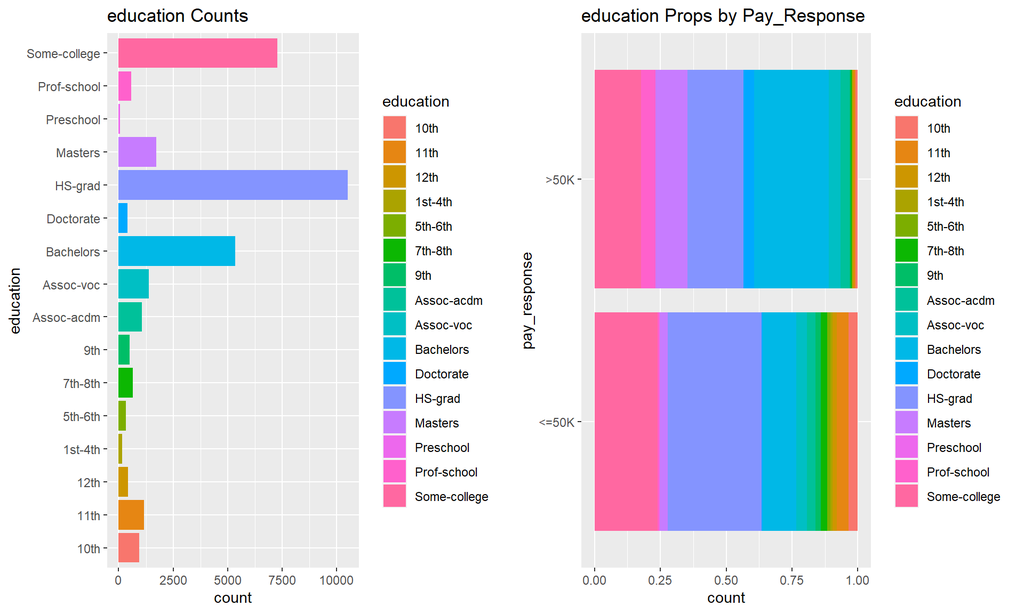

```r
count <- ggplot(df_train, aes(y=education, fill=education)) + geom_bar() + labs(title='education Counts')
prop <- ggplot(df_train, aes(y=pay_response, fill=education)) + geom_bar(position='fill') + labs(title='education Props by Pay_Response')

ggarrange(count, prop, nrow=1, ncol=2)
```

COUNTS : First thought, we should refactor these to order them from least to most experience. A lot of groups here…may be best to categorize into smaller groups (<high school, high-school, ba, ma, phd). Very cool that there is no ?.

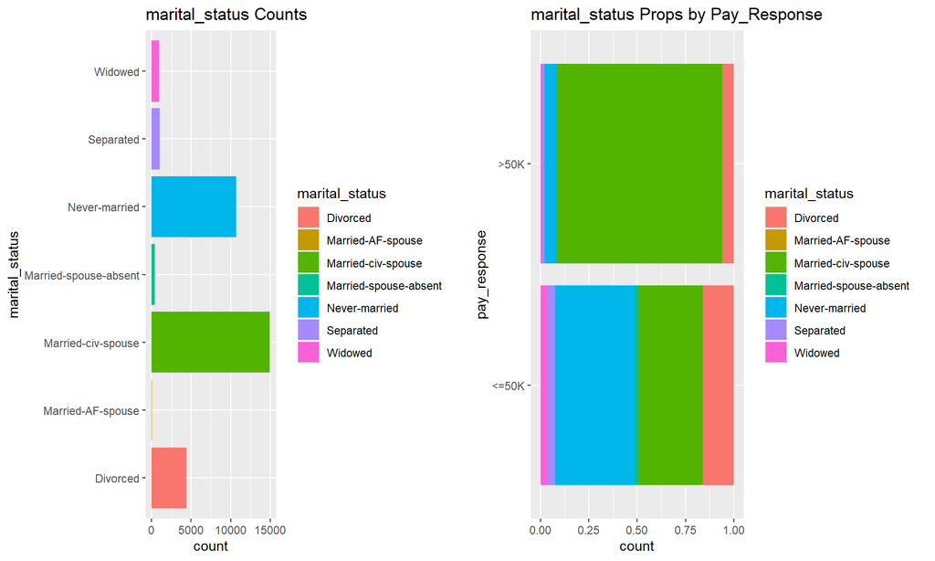

```r
count <- ggplot(df_train, aes(y=marital_status, fill=marital_status)) + geom_bar() + labs(title='marital_status Counts')
prop <- ggplot(df_train, aes(y=pay_response, fill=marital_status)) + geom_bar(position='fill') + labs(title='marital_status Props by Pay_Response')

ggarrange(count, prop, nrow=1, ncol=2)
```

COUNTS: Nothing significant here. No missing values though, so that’s good. Again, consolidating some of these groups could maybe help create more significant groups within models.

PROPS: Big news here is that Never-married (and divorced, to a lesser extent) drops SIGNIFICANTLY between <50K and >50K. The ‘Married-civ-spouse’ group sees the opposite change.

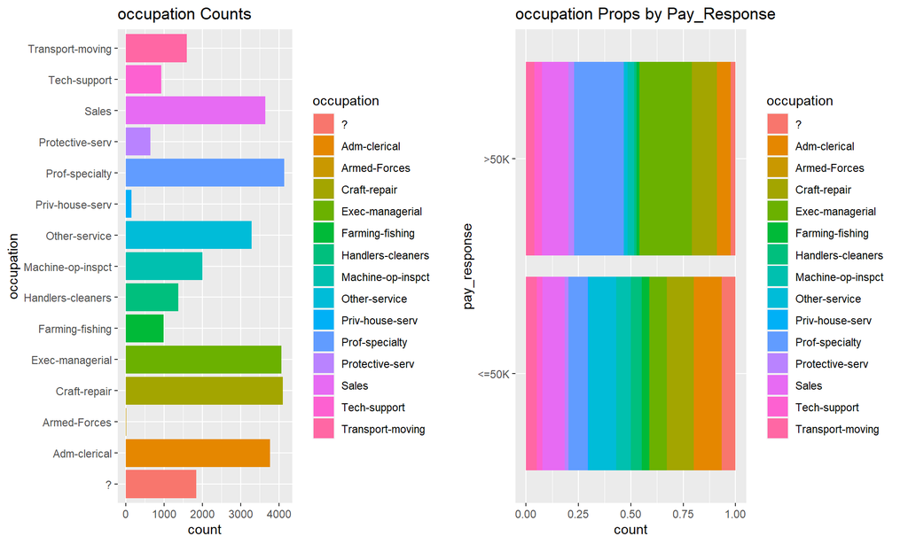

```r
count <- ggplot(df_train, aes(y=occupation, fill=occupation)) + geom_bar() + labs(title='occupation Counts')
prop <- ggplot(df_train, aes(y=pay_response, fill=occupation)) + geom_bar(position='fill') + labs(title='occupation Props by Pay_Response')

ggarrange(count, prop, nrow=1, ncol=2)
```

COUNTS: Lots of groups here, again. About 2000 ? values (can’t be removed, not sure how we could impute them).

PROPS: Some significance here. Exec-managerial and Prof-specialty appear much more in >50K.

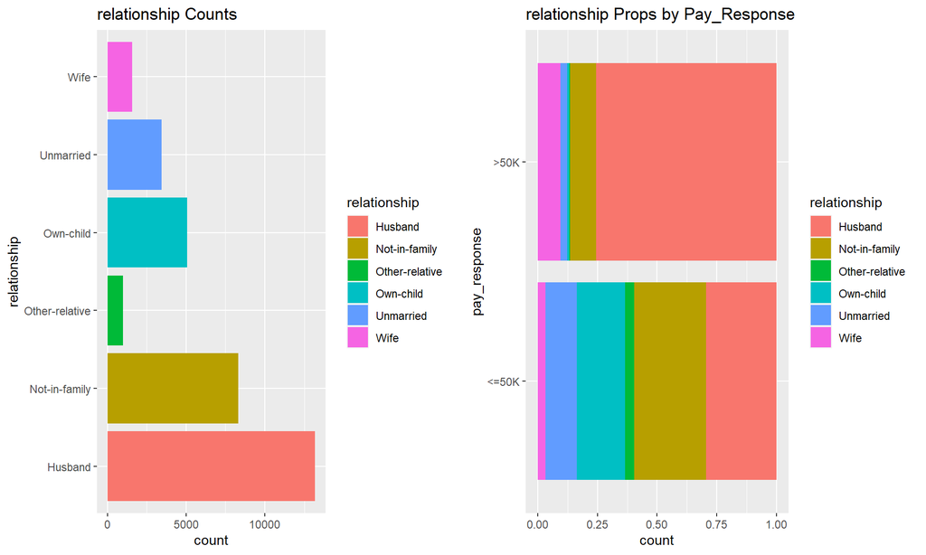

```r
count <- ggplot(df_train, aes(y=relationship, fill=relationship)) + geom_bar() + labs(title='relationship Counts')
prop <- ggplot(df_train, aes(y=pay_response, fill=relationship)) + geom_bar(position='fill') + labs(title='relationship Props by Pay_Response')

ggarrange(count, prop, nrow=1, ncol=2)
```

COUNTS : Not sure what this variable means. Will do some more research. No ?’s though!

PROPS : <=50K is pretty consistent across all groups (much more so than the other variables). Although, >50K sees a large majority of ‘Husband’.

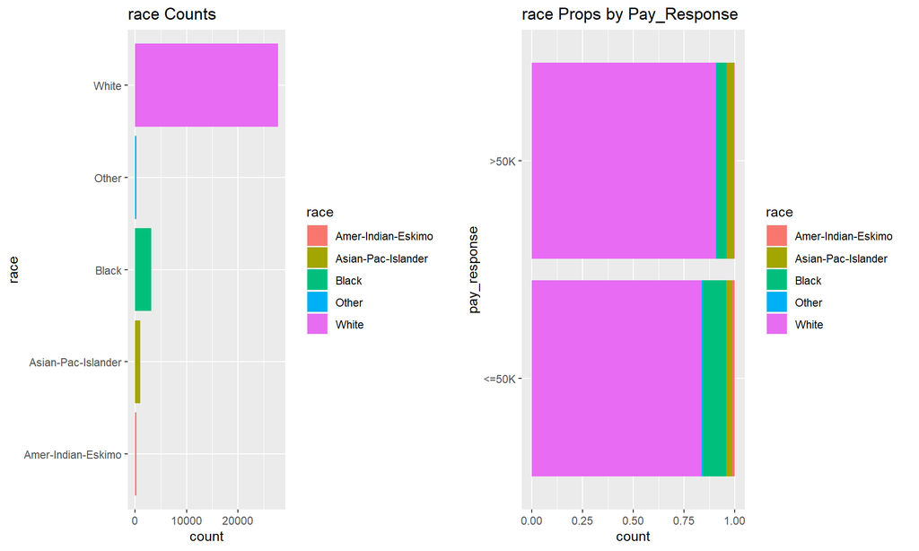

```r
count <- ggplot(df_train, aes(y=race, fill=race)) + geom_bar() + labs(title='race Counts')
prop <- ggplot(df_train, aes(y=pay_response, fill=race)) + geom_bar(position='fill') + labs(title='race Props by Pay_Response')

ggarrange(count, prop, nrow=1, ncol=2)
```

COUNTS : Was surprised by the counts at first – this data is from 1994.

PROPS : Not much of a difference between groups.

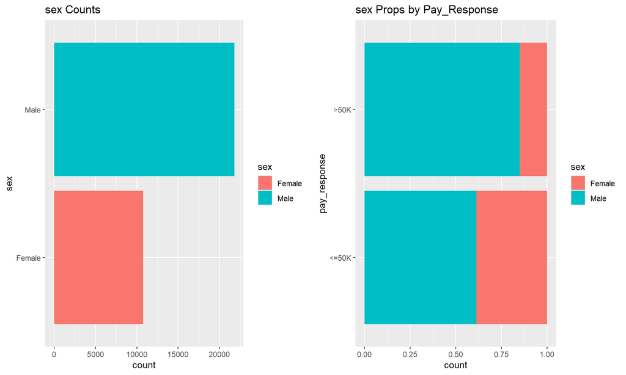

```r
count <- ggplot(df_train, aes(y=sex, fill=sex)) + geom_bar() + labs(title='sex Counts')
prop <- ggplot(df_train, aes(y=pay_response, fill=sex)) + geom_bar(position='fill') + labs(title='sex Props by Pay_Response')

ggarrange(count, prop, nrow=1, ncol=2)
```

COUNTS : Very surprised about the counts here. I’ll have to do more research into how this data is collected.

PROPS : Pretty close to what I would expect from 1994.

[figure not shown]

```r
count <- ggplot(df_train, aes(y=native_country, fill=native_country)) + geom_bar() + labs(title='native_country Counts')
prop <- ggplot(df_train, aes(y=pay_response, fill=native_country)) + geom_bar(position='fill') + labs(title='native_country Props by Pay_Response')

ggarrange(count, prop, nrow=1, ncol=2)
```

COUNTS : I know this is a mess…leaving it here to suggest grouping these by continent.

PROPS : Same comment as above. But it makes sense that the US is dominant in proportion and count here.

# MY CONCLUSIONS:

Some of these variables have significant relationships with the reponse, some are a little harder to shoehorn into that relationship.

Maybe create Capital_Gain - Capital_Loss variable? Might help us understand the >50K population at high Cap_Loss values.

Consolidate groups…Education/Country/Marital_Status, etc.

The ? values are concerning, especially considering that I can’t think of a way to impute them…we’ll have to talk about that.